# Risk Factor Analysis

## Outcome Variable

**Outcome Variable:** pers_wasted624

## Predictor Variables

**Intervention Variable:** ever_sstunted06

**Adjustment Set:**

- sex
- arm
- brthmon
- vagbrth
- single
- W_mage
- W_mhtcm
- W_mwtkg
- W_mbmi
- W_meducyrs
- W_feducyrs
- W_parity
- delta_brthmon
- delta_vagbrth
- delta_single
- delta_W_mage
- delta_W_mhtcm
- delta_W_mwtkg
- delta_W_mbmi
- delta_W_meducyrs
- delta_W_feducyrs
- delta_W_parity

## Stratifying Variables

The analysis was stratified on these variable(s):

- studyid
- country

## Data Summary

| studyid | country | ever_sstunted06 | pers_wasted624 | n_cell | n |
| --- | --- | --- | --- | --- | --- |
| ki0047075b-MAL-ED | BANGLADESH | 0 | 0 | 207 | 240 |
| ki0047075b-MAL-ED | BANGLADESH | 0 | 1 | 15 | 240 |
| ki0047075b-MAL-ED | BANGLADESH | 1 | 0 | 16 | 240 |
| ki0047075b-MAL-ED | BANGLADESH | 1 | 1 | 2 | 240 |
| ki0047075b-MAL-ED | BRAZIL | 0 | 0 | 188 | 207 |
| ki0047075b-MAL-ED | BRAZIL | 0 | 1 | 2 | 207 |
| ki0047075b-MAL-ED | BRAZIL | 1 | 0 | 17 | 207 |
| ki0047075b-MAL-ED | BRAZIL | 1 | 1 | 0 | 207 |
| ki0047075b-MAL-ED | INDIA | 0 | 0 | 193 | 235 |
| ki0047075b-MAL-ED | INDIA | 0 | 1 | 22 | 235 |
| ki0047075b-MAL-ED | INDIA | 1 | 0 | 14 | 235 |
| ki0047075b-MAL-ED | INDIA | 1 | 1 | 6 | 235 |
| ki0047075b-MAL-ED | NEPAL | 0 | 0 | 224 | 235 |
| ki0047075b-MAL-ED | NEPAL | 0 | 1 | 1 | 235 |
| ki0047075b-MAL-ED | NEPAL | 1 | 0 | 9 | 235 |
| ki0047075b-MAL-ED | NEPAL | 1 | 1 | 1 | 235 |
| ki0047075b-MAL-ED | PERU | 0 | 0 | 234 | 270 |
| ki0047075b-MAL-ED | PERU | 0 | 1 | 1 | 270 |
| ki0047075b-MAL-ED | PERU | 1 | 0 | 33 | 270 |
| ki0047075b-MAL-ED | PERU | 1 | 1 | 2 | 270 |
| ki0047075b-MAL-ED | SOUTH AFRICA | 0 | 0 | 230 | 259 |
| ki0047075b-MAL-ED | SOUTH AFRICA | 0 | 1 | 2 | 259 |
| ki0047075b-MAL-ED | SOUTH AFRICA | 1 | 0 | 27 | 259 |
| ki0047075b-MAL-ED | SOUTH AFRICA | 1 | 1 | 0 | 259 |
| ki0047075b-MAL-ED | TANZANIA, UNITED REPUBLIC OF | 0 | 0 | 208 | 245 |
| ki0047075b-MAL-ED | TANZANIA, UNITED REPUBLIC OF | 0 | 1 | 0 | 245 |
| ki0047075b-MAL-ED | TANZANIA, UNITED REPUBLIC OF | 1 | 0 | 37 | 245 |
| ki0047075b-MAL-ED | TANZANIA, UNITED REPUBLIC OF | 1 | 1 | 0 | 245 |
| ki1000108-CMC-V-BCS-2002 | INDIA | 0 | 0 | 260 | 370 |
| ki1000108-CMC-V-BCS-2002 | INDIA | 0 | 1 | 16 | 370 |

[output cut: 90 more lines]

The following strata were considered:

- studyid: ki0047075b-MAL-ED, country: BANGLADESH
- studyid: ki0047075b-MAL-ED, country: BRAZIL
- studyid: ki0047075b-MAL-ED, country: INDIA
- studyid: ki0047075b-MAL-ED, country: NEPAL
- studyid: ki0047075b-MAL-ED, country: PERU
- studyid: ki0047075b-MAL-ED, country: SOUTH AFRICA
- studyid: ki0047075b-MAL-ED, country: TANZANIA, UNITED REPUBLIC OF
- studyid: ki1000108-CMC-V-BCS-2002, country: INDIA
- studyid: ki1000108-IRC, country: INDIA
- studyid: ki1000109-EE, country: PAKISTAN
- studyid: ki1000109-ResPak, country: PAKISTAN
- studyid: ki1000304b-SAS-CompFeed, country: INDIA
- studyid: ki1000304b-SAS-FoodSuppl, country: INDIA
- studyid: ki1017093-NIH-Birth, country: BANGLADESH
- studyid: ki1017093b-PROVIDE, country: BANGLADESH
- studyid: ki1017093c-NIH-Crypto, country: BANGLADESH
- studyid: ki1066203-TanzaniaChild2, country: TANZANIA, UNITED REPUBLIC OF
- studyid: ki1101329-Keneba, country: GAMBIA
- studyid: ki1112895-Guatemala BSC, country: GUATEMALA
- studyid: ki1113344-GMS-Nepal, country: NEPAL
- studyid: ki1114097-CMIN, country: BANGLADESH
- studyid: ki1114097-CONTENT, country: PERU
- studyid: ki1119695-PROBIT, country: BELARUS
- studyid: ki1126311-ZVITAMBO, country: ZIMBABWE
- studyid: ki1135781-COHORTS, country: GUATEMALA
- studyid: ki1135781-COHORTS, country: INDIA
- studyid: ki1135781-COHORTS, country: PHILIPPINES
- studyid: ki1148112-LCNI-5, country: MALAWI
- studyid: kiGH5241-JiVitA-3, country: BANGLADESH
- studyid: kiGH5241-JiVitA-4, country: BANGLADESH

### Dropped Strata

Some strata were dropped due to rare outcomes:

- studyid: ki0047075b-MAL-ED, country: BANGLADESH
- studyid: ki0047075b-MAL-ED, country: BRAZIL
- studyid: ki0047075b-MAL-ED, country: NEPAL
- studyid: ki0047075b-MAL-ED, country: PERU
- studyid: ki0047075b-MAL-ED, country: SOUTH AFRICA
- studyid: ki0047075b-MAL-ED, country: TANZANIA, UNITED REPUBLIC OF
- studyid: ki1017093b-PROVIDE, country: BANGLADESH
- studyid: ki1112895-Guatemala BSC, country: GUATEMALA
- studyid: ki1114097-CONTENT, country: PERU
- studyid: ki1119695-PROBIT, country: BELARUS
- studyid: ki1148112-LCNI-5, country: MALAWI

## Methods Detail

We’re interested in the causal parameters $E[Y_a]$ for all values of $a \in \mathcal{A}$. These parameters represent the mean outcome if, possibly contrary to fact, we intervened to set all units to have $A=a$. Under the randomization and positivity assumptions, these are identified by the statistical parameters $\psi_a=E_W[E_{Y|A,W}(Y|A=a,W)]$. In addition, we’re interested in the mean of $Y$, $E[Y]$ under no intervention (the observed mean). We will estimate these parameters by using SuperLearner to fit the relevant likelihood factors – $E_{Y|A,W}(Y|A=a,W)$ and $p(A=a|W)$, and then updating our likelihood fit using a joint TMLE.

For unadjusted analyses ($W=\{\}$), initial likelihoods were estimated using Lrnr_glm to estimate the simple $E(Y|A)$ and Lrnr_mean to estimate $p(A)$. For adjusted analyses, a small library containing Lrnr_glmnet, Lrnr_xgboost, and Lrnr_mean was used.

Having estimated these parameters, we will then use the delta method to estimate relative risks and attributable risks relative to a prespecified baseline level of $A$.

# Results Detail

## Results Plots

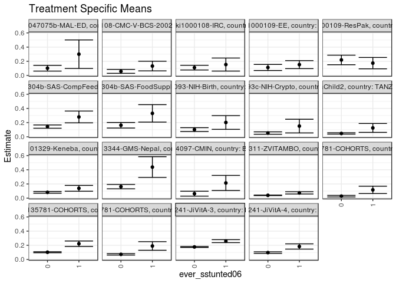

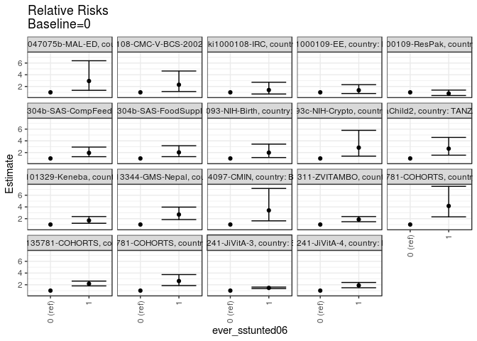

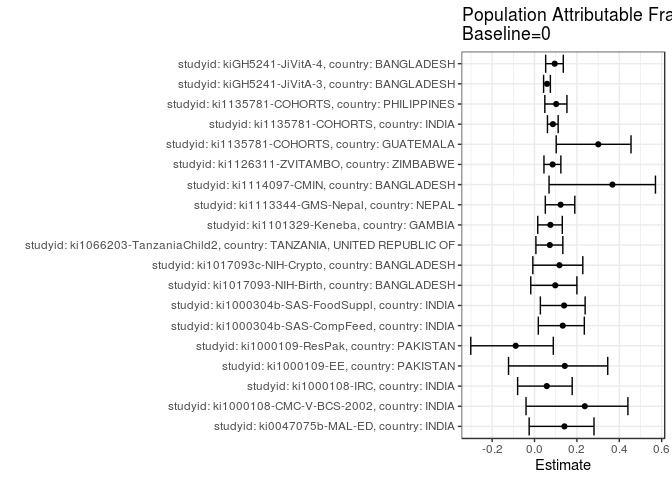

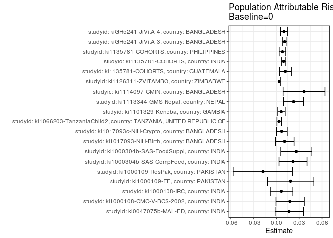

## Results Table

### Parameter: TSM

| studyid | country | intervention_level | baseline_level | estimate | ci_lower | ci_upper |
| --- | --- | --- | --- | --- | --- | --- |
| ki0047075b-MAL-ED | INDIA | 0 | NA | 0.1023256 | 0.0617274 | 0.1429237 |
| ki0047075b-MAL-ED | INDIA | 1 | NA | 0.3000000 | 0.0987348 | 0.5012652 |
| ki1000108-CMC-V-BCS-2002 | INDIA | 0 | NA | 0.0577161 | 0.0300435 | 0.0853887 |
| ki1000108-CMC-V-BCS-2002 | INDIA | 1 | NA | 0.1326594 | 0.0645894 | 0.2007294 |
| ki1000108-IRC | INDIA | 0 | NA | 0.1103119 | 0.0770585 | 0.1435652 |
| ki1000108-IRC | INDIA | 1 | NA | 0.1537568 | 0.0618972 | 0.2456163 |
| ki1000109-EE | PAKISTAN | 0 | NA | 0.1126101 | 0.0696241 | 0.1555961 |
| ki1000109-EE | PAKISTAN | 1 | NA | 0.1529261 | 0.0966216 | 0.2092306 |
| ki1000109-ResPak | PAKISTAN | 0 | NA | 0.2187022 | 0.1512369 | 0.2861676 |
| ki1000109-ResPak | PAKISTAN | 1 | NA | 0.1739978 | 0.0939061 | 0.2540895 |
| ki1000304b-SAS-CompFeed | INDIA | 0 | NA | 0.1436339 | 0.1206548 | 0.1666129 |
| ki1000304b-SAS-CompFeed | INDIA | 1 | NA | 0.2799046 | 0.1968329 | 0.3629762 |
| ki1000304b-SAS-FoodSuppl | INDIA | 0 | NA | 0.1626498 | 0.1232355 | 0.2020640 |
| ki1000304b-SAS-FoodSuppl | INDIA | 1 | NA | 0.3305159 | 0.2072010 | 0.4538309 |
| ki1017093-NIH-Birth | BANGLADESH | 0 | NA | 0.1015552 | 0.0743909 | 0.1287194 |
| ki1017093-NIH-Birth | BANGLADESH | 1 | NA | 0.2019047 | 0.1051119 | 0.2986974 |
| ki1017093c-NIH-Crypto | BANGLADESH | 0 | NA | 0.0531758 | 0.0362619 | 0.0700896 |
| ki1017093c-NIH-Crypto | BANGLADESH | 1 | NA | 0.1509434 | 0.0544976 | 0.2473892 |
| ki1066203-TanzaniaChild2 | TANZANIA, UNITED REPUBLIC OF | 0 | NA | 0.0468927 | 0.0374259 | 0.0563595 |
| ki1066203-TanzaniaChild2 | TANZANIA, UNITED REPUBLIC OF | 1 | NA | 0.1251502 | 0.0623437 | 0.1879567 |
| ki1101329-Keneba | GAMBIA | 0 | NA | 0.0816850 | 0.0697432 | 0.0936268 |
| ki1101329-Keneba | GAMBIA | 1 | NA | 0.1383887 | 0.0971024 | 0.1796750 |
| ki1113344-GMS-Nepal | NEPAL | 0 | NA | 0.1619847 | 0.1309298 | 0.1930396 |
| ki1113344-GMS-Nepal | NEPAL | 1 | NA | 0.4381283 | 0.2917666 | 0.5844899 |
| ki1114097-CMIN | BANGLADESH | 0 | NA | 0.0627303 | 0.0283865 | 0.0970742 |
| ki1114097-CMIN | BANGLADESH | 1 | NA | 0.2141559 | 0.1075611 | 0.3207506 |
| ki1126311-ZVITAMBO | ZIMBABWE | 0 | NA | 0.0395454 | 0.0356365 | 0.0434542 |
| ki1126311-ZVITAMBO | ZIMBABWE | 1 | NA | 0.0739493 | 0.0582829 | 0.0896158 |
| ki1135781-COHORTS | GUATEMALA | 0 | NA | 0.0280207 | 0.0169887 | 0.0390526 |
| ki1135781-COHORTS | GUATEMALA | 1 | NA | 0.1168220 | 0.0651788 | 0.1684652 |
| ki1135781-COHORTS | INDIA | 0 | NA | 0.1021610 | 0.0947537 | 0.1095684 |
| ki1135781-COHORTS | INDIA | 1 | NA | 0.2223679 | 0.1838196 | 0.2609163 |
| ki1135781-COHORTS | PHILIPPINES | 0 | NA | 0.0722263 | 0.0622281 | 0.0822244 |
| ki1135781-COHORTS | PHILIPPINES | 1 | NA | 0.1904134 | 0.1294534 | 0.2513733 |
| kiGH5241-JiVitA-3 | BANGLADESH | 0 | NA | 0.1767084 | 0.1697360 | 0.1836809 |
| kiGH5241-JiVitA-3 | BANGLADESH | 1 | NA | 0.2589799 | 0.2378450 | 0.2801148 |
| kiGH5241-JiVitA-4 | BANGLADESH | 0 | NA | 0.0970788 | 0.0860300 | 0.1081275 |
| kiGH5241-JiVitA-4 | BANGLADESH | 1 | NA | 0.1835142 | 0.1463423 | 0.2206861 |

### Parameter: E(Y)

| studyid | country | intervention_level | baseline_level | estimate | ci_lower | ci_upper |
| --- | --- | --- | --- | --- | --- | --- |
| ki0047075b-MAL-ED | INDIA | NA | NA | 0.1191489 | 0.0776405 | 0.1606574 |
| ki1000108-CMC-V-BCS-2002 | INDIA | NA | NA | 0.0756757 | 0.0486905 | 0.1026609 |
| ki1000108-IRC | INDIA | NA | NA | 0.1170732 | 0.0859146 | 0.1482317 |
| ki1000109-EE | PAKISTAN | NA | NA | 0.1313673 | 0.0970401 | 0.1656945 |
| ki1000109-ResPak | PAKISTAN | NA | NA | 0.2008547 | 0.1494120 | 0.2522974 |
| ki1000304b-SAS-CompFeed | INDIA | NA | NA | 0.1657061 | 0.1471754 | 0.1842367 |
| ki1000304b-SAS-FoodSuppl | INDIA | NA | NA | 0.1890547 | 0.1507312 | 0.2273783 |
| ki1017093-NIH-Birth | BANGLADESH | NA | NA | 0.1125461 | 0.0859151 | 0.1391771 |
| ki1017093c-NIH-Crypto | BANGLADESH | NA | NA | 0.0602740 | 0.0429977 | 0.0775502 |
| ki1066203-TanzaniaChild2 | TANZANIA, UNITED REPUBLIC OF | NA | NA | 0.0505451 | 0.0409848 | 0.0601054 |
| ki1101329-Keneba | GAMBIA | NA | NA | 0.0882993 | 0.0766987 | 0.0998998 |
| ki1113344-GMS-Nepal | NEPAL | NA | NA | 0.1847458 | 0.1534039 | 0.2160876 |
| ki1114097-CMIN | BANGLADESH | NA | NA | 0.0992063 | 0.0622241 | 0.1361886 |
| ki1126311-ZVITAMBO | ZIMBABWE | NA | NA | 0.0432327 | 0.0393972 | 0.0470683 |
| ki1135781-COHORTS | GUATEMALA | NA | NA | 0.0400782 | 0.0280529 | 0.0521035 |
| ki1135781-COHORTS | INDIA | NA | NA | 0.1118526 | 0.1044114 | 0.1192938 |
| ki1135781-COHORTS | PHILIPPINES | NA | NA | 0.0804557 | 0.0703953 | 0.0905161 |
| kiGH5241-JiVitA-3 | BANGLADESH | NA | NA | 0.1877787 | 0.1812440 | 0.1943134 |
| kiGH5241-JiVitA-4 | BANGLADESH | NA | NA | 0.1072855 | 0.0967458 | 0.1178252 |

### Parameter: RR

| studyid | country | intervention_level | baseline_level | estimate | ci_lower | ci_upper |
| --- | --- | --- | --- | --- | --- | --- |
| ki0047075b-MAL-ED | INDIA | 0 | 0 | 1.0000000 | 1.0000000 | 1.000000 |
| ki0047075b-MAL-ED | INDIA | 1 | 0 | 2.9318182 | 1.3447391 | 6.391989 |
| ki1000108-CMC-V-BCS-2002 | INDIA | 0 | 0 | 1.0000000 | 1.0000000 | 1.000000 |
| ki1000108-CMC-V-BCS-2002 | INDIA | 1 | 0 | 2.2984809 | 1.1386600 | 4.639677 |
| ki1000108-IRC | INDIA | 0 | 0 | 1.0000000 | 1.0000000 | 1.000000 |
| ki1000108-IRC | INDIA | 1 | 0 | 1.3938370 | 0.7136862 | 2.722179 |
| ki1000109-EE | PAKISTAN | 0 | 0 | 1.0000000 | 1.0000000 | 1.000000 |
| ki1000109-EE | PAKISTAN | 1 | 0 | 1.3580136 | 0.7991365 | 2.307742 |
| ki1000109-ResPak | PAKISTAN | 0 | 0 | 1.0000000 | 1.0000000 | 1.000000 |
| ki1000109-ResPak | PAKISTAN | 1 | 0 | 0.7955922 | 0.4577107 | 1.382897 |
| ki1000304b-SAS-CompFeed | INDIA | 0 | 0 | 1.0000000 | 1.0000000 | 1.000000 |
| ki1000304b-SAS-CompFeed | INDIA | 1 | 0 | 1.9487365 | 1.2936787 | 2.935485 |
| ki1000304b-SAS-FoodSuppl | INDIA | 0 | 0 | 1.0000000 | 1.0000000 | 1.000000 |
| ki1000304b-SAS-FoodSuppl | INDIA | 1 | 0 | 2.0320715 | 1.3018280 | 3.171936 |
| ki1017093-NIH-Birth | BANGLADESH | 0 | 0 | 1.0000000 | 1.0000000 | 1.000000 |
| ki1017093-NIH-Birth | BANGLADESH | 1 | 0 | 1.9881280 | 1.1484889 | 3.441612 |
| ki1017093c-NIH-Crypto | BANGLADESH | 0 | 0 | 1.0000000 | 1.0000000 | 1.000000 |
| ki1017093c-NIH-Crypto | BANGLADESH | 1 | 0 | 2.8385744 | 1.3903512 | 5.795302 |
| ki1066203-TanzaniaChild2 | TANZANIA, UNITED REPUBLIC OF | 0 | 0 | 1.0000000 | 1.0000000 | 1.000000 |
| ki1066203-TanzaniaChild2 | TANZANIA, UNITED REPUBLIC OF | 1 | 0 | 2.6688648 | 1.5533706 | 4.585409 |
| ki1101329-Keneba | GAMBIA | 0 | 0 | 1.0000000 | 1.0000000 | 1.000000 |
| ki1101329-Keneba | GAMBIA | 1 | 0 | 1.6941750 | 1.2161225 | 2.360148 |
| ki1113344-GMS-Nepal | NEPAL | 0 | 0 | 1.0000000 | 1.0000000 | 1.000000 |
| ki1113344-GMS-Nepal | NEPAL | 1 | 0 | 2.7047506 | 1.8413955 | 3.972898 |
| ki1114097-CMIN | BANGLADESH | 0 | 0 | 1.0000000 | 1.0000000 | 1.000000 |
| ki1114097-CMIN | BANGLADESH | 1 | 0 | 3.4139122 | 1.6277101 | 7.160241 |
| ki1126311-ZVITAMBO | ZIMBABWE | 0 | 0 | 1.0000000 | 1.0000000 | 1.000000 |
| ki1126311-ZVITAMBO | ZIMBABWE | 1 | 0 | 1.8699866 | 1.4804644 | 2.361995 |
| ki1135781-COHORTS | GUATEMALA | 0 | 0 | 1.0000000 | 1.0000000 | 1.000000 |
| ki1135781-COHORTS | GUATEMALA | 1 | 0 | 4.1691362 | 2.3118940 | 7.518379 |
| ki1135781-COHORTS | INDIA | 0 | 0 | 1.0000000 | 1.0000000 | 1.000000 |
| ki1135781-COHORTS | INDIA | 1 | 0 | 2.1766416 | 1.8042448 | 2.625901 |
| ki1135781-COHORTS | PHILIPPINES | 0 | 0 | 1.0000000 | 1.0000000 | 1.000000 |
| ki1135781-COHORTS | PHILIPPINES | 1 | 0 | 2.6363442 | 1.8601098 | 3.736506 |
| kiGH5241-JiVitA-3 | BANGLADESH | 0 | 0 | 1.0000000 | 1.0000000 | 1.000000 |
| kiGH5241-JiVitA-3 | BANGLADESH | 1 | 0 | 1.4655777 | 1.3397385 | 1.603237 |
| kiGH5241-JiVitA-4 | BANGLADESH | 0 | 0 | 1.0000000 | 1.0000000 | 1.000000 |
| kiGH5241-JiVitA-4 | BANGLADESH | 1 | 0 | 1.8903637 | 1.4938232 | 2.392167 |

### Parameter: PAR

| studyid | country | intervention_level | baseline_level | estimate | ci_lower | ci_upper |
| --- | --- | --- | --- | --- | --- | --- |
| ki0047075b-MAL-ED | INDIA | 0 | NA | 0.0168234 | -0.0020257 | 0.0356724 |
| ki1000108-CMC-V-BCS-2002 | INDIA | 0 | NA | 0.0179595 | -0.0008746 | 0.0367937 |
| ki1000108-IRC | INDIA | 0 | NA | 0.0067613 | -0.0083354 | 0.0218580 |
| ki1000109-EE | PAKISTAN | 0 | NA | 0.0187572 | -0.0118552 | 0.0493696 |
| ki1000109-ResPak | PAKISTAN | 0 | NA | -0.0178475 | -0.0569238 | 0.0212288 |
| ki1000304b-SAS-CompFeed | INDIA | 0 | NA | 0.0220722 | 0.0037418 | 0.0404026 |
| ki1000304b-SAS-FoodSuppl | INDIA | 0 | NA | 0.0264050 | 0.0060493 | 0.0467607 |
| ki1017093-NIH-Birth | BANGLADESH | 0 | NA | 0.0109910 | -0.0014577 | 0.0234396 |
| ki1017093c-NIH-Crypto | BANGLADESH | 0 | NA | 0.0070982 | -0.0002455 | 0.0144419 |
| ki1066203-TanzaniaChild2 | TANZANIA, UNITED REPUBLIC OF | 0 | NA | 0.0036524 | 0.0003765 | 0.0069284 |
| ki1101329-Keneba | GAMBIA | 0 | NA | 0.0066143 | 0.0014373 | 0.0117912 |
| ki1113344-GMS-Nepal | NEPAL | 0 | NA | 0.0227610 | 0.0095986 | 0.0359235 |
| ki1114097-CMIN | BANGLADESH | 0 | NA | 0.0364760 | 0.0090740 | 0.0638781 |
| ki1126311-ZVITAMBO | ZIMBABWE | 0 | NA | 0.0036874 | 0.0019327 | 0.0054421 |
| ki1135781-COHORTS | GUATEMALA | 0 | NA | 0.0120575 | 0.0042326 | 0.0198824 |
| ki1135781-COHORTS | INDIA | 0 | NA | 0.0096916 | 0.0068061 | 0.0125771 |
| ki1135781-COHORTS | PHILIPPINES | 0 | NA | 0.0082294 | 0.0039227 | 0.0125361 |
| kiGH5241-JiVitA-3 | BANGLADESH | 0 | NA | 0.0110703 | 0.0080614 | 0.0140792 |
| kiGH5241-JiVitA-4 | BANGLADESH | 0 | NA | 0.0102068 | 0.0057625 | 0.0146510 |

### Parameter: PAF

| studyid | country | intervention_level | baseline_level | estimate | ci_lower | ci_upper |
| --- | --- | --- | --- | --- | --- | --- |
| ki0047075b-MAL-ED | INDIA | 0 | NA | 0.1411960 | -0.0253403 | 0.2806834 |
| ki1000108-CMC-V-BCS-2002 | INDIA | 0 | NA | 0.2373225 | -0.0400291 | 0.4407109 |
| ki1000108-IRC | INDIA | 0 | NA | 0.0577528 | -0.0797455 | 0.1777416 |
| ki1000109-EE | PAKISTAN | 0 | NA | 0.1427842 | -0.1226720 | 0.3454732 |
| ki1000109-ResPak | PAKISTAN | 0 | NA | -0.0888580 | -0.3009014 | 0.0886229 |
| ki1000304b-SAS-CompFeed | INDIA | 0 | NA | 0.1332008 | 0.0178675 | 0.2349903 |
| ki1000304b-SAS-FoodSuppl | INDIA | 0 | NA | 0.1396684 | 0.0275529 | 0.2388578 |
| ki1017093-NIH-Birth | BANGLADESH | 0 | NA | 0.0976574 | -0.0177521 | 0.1999799 |
| ki1017093c-NIH-Crypto | BANGLADESH | 0 | NA | 0.1177655 | -0.0080550 | 0.2278818 |
| ki1066203-TanzaniaChild2 | TANZANIA, UNITED REPUBLIC OF | 0 | NA | 0.0722607 | 0.0065260 | 0.1336459 |
| ki1101329-Keneba | GAMBIA | 0 | NA | 0.0749073 | 0.0151424 | 0.1310455 |
| ki1113344-GMS-Nepal | NEPAL | 0 | NA | 0.1232020 | 0.0509306 | 0.1899699 |
| ki1114097-CMIN | BANGLADESH | 0 | NA | 0.3676782 | 0.0685226 | 0.5707563 |
| ki1126311-ZVITAMBO | ZIMBABWE | 0 | NA | 0.0852910 | 0.0445343 | 0.1243091 |
| ki1135781-COHORTS | GUATEMALA | 0 | NA | 0.3008500 | 0.1024247 | 0.4554098 |
| ki1135781-COHORTS | INDIA | 0 | NA | 0.0866460 | 0.0610433 | 0.1115506 |
| ki1135781-COHORTS | PHILIPPINES | 0 | NA | 0.1022848 | 0.0486256 | 0.1529175 |
| kiGH5241-JiVitA-3 | BANGLADESH | 0 | NA | 0.0589541 | 0.0428263 | 0.0748102 |
| kiGH5241-JiVitA-4 | BANGLADESH | 0 | NA | 0.0951364 | 0.0525604 | 0.1357992 |